# Data Project 1

MariAlejandra Ginorio

2021-02-28

## Problem statement

In this project, I have been given a text file with chess tournament results where the information has some structure. My job is to create an R Markdown file that generates a .CSV file (that could for example be imported into a SQL database) with the following information for all of the players:

| Player’s Name | Player’s State | Total Number of Points | Player’s Pre-Rating | Average Pre-Chess Rating of Opponenets |
| --- | --- | --- | --- | --- |
| GARY HUA | ON | 6 | 1794 | 1605 |

1605 was calculated by using the pre-tournament opponents’ ratings of 1436, 1563, 1600, 1610, 1649, 1663, 1716, and dividing by the total number of games played.

### Data in Text File

The chess tournament text file is written in a format that is not legible in R. This file needs to be re-structured in order to find the average pre-tournament score.

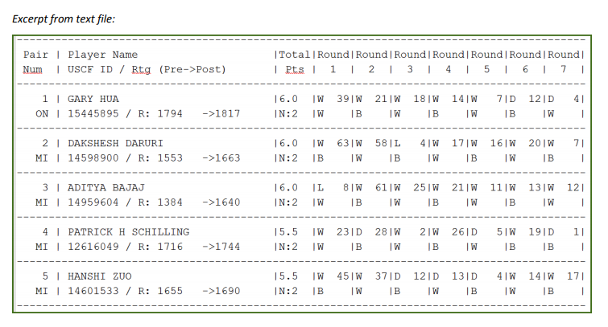

Data in text file

### Packages:

- Stringr
- Tydyverse
- Dplryr

### Key Methods

*Using Github URL*

https://raw.githubusercontent.com/mgino11/Cleanup_txt_str/main/tournamentinfo.txt

#### *Deconstruct Data*

In this data set we already know that the first 4 lines are not part of our data because they include – dash lines, Pair, Num, Dash lines. in addition, we need to extract the data using sequences to be able to see data better and take direction from what we see. In this case we will divide the data in 2 matrices.

- Matrix 1 = the sequence starts at row 5 with length (chess1)
- Matrix 2 = the sequence starts at row 6 with length (chess1)

**See Code**

```r
chess_data <- read.csv(file = "https://raw.githubusercontent.com/mgino11/Cleanup_txt_str/main/tournamentinfo.txt", skip = 3, header = F)

# Create a Matrix and create a sequence
chess1 <- matrix(unlist(chess_data), byrow = TRUE)
matrix_chess1 <- chess1[seq(5, length(chess1), 3)]
head(matrix_chess1)
```

```
## [1] "    2 | DAKSHESH DARURI                 |6.0  |W  63|W  58|L   4|W  17|W  16|W  20|W   7|"
## [2] "    3 | ADITYA BAJAJ                    |6.0  |L   8|W  61|W  25|W  21|W  11|W  13|W  12|"
## [3] "    4 | PATRICK H SCHILLING             |5.5  |W  23|D  28|W   2|W  26|D   5|W  19|D   1|"
## [4] "    5 | HANSHI ZUO                      |5.5  |W  45|W  37|D  12|D  13|D   4|W  14|W  17|"
## [5] "    6 | HANSEN SONG                     |5.0  |W  34|D  29|L  11|W  35|D  10|W  27|W  21|"
## [6] "    7 | GARY DEE SWATHELL               |5.0  |W  57|W  46|W  13|W  11|L   1|W   9|L   2|"
```

```r
matrix_chess2 <- chess1[seq(6,length(chess1),3)]
head(matrix_chess2)
```

```
## [1] "   MI | 14598900 / R: 1553   ->1663     |N:2  |B    |W    |B    |W    |B    |W    |B    |"
## [2] "   MI | 14959604 / R: 1384   ->1640     |N:2  |W    |B    |W    |B    |W    |B    |W    |"
## [3] "   MI | 12616049 / R: 1716   ->1744     |N:2  |W    |B    |W    |B    |W    |B    |B    |"
## [4] "   MI | 14601533 / R: 1655   ->1690     |N:2  |B    |W    |B    |W    |B    |W    |B    |"
## [5] "   OH | 15055204 / R: 1686   ->1687     |N:3  |W    |B    |W    |B    |B    |W    |B    |"
## [6] "   MI | 11146376 / R: 1649   ->1673     |N:3  |W    |B    |W    |B    |B    |W    |W    |"
```